# ProjetAD

### *Choix des axes :

```r
library(FactoMineR)
```

```r
X=ques[,39:49]
res.pca=PCA(X,ncp = 5,graph = F)
head(res.pca$eig)
```

```
##        eigenvalue percentage of variance cumulative percentage of variance
## comp 1  6.7935040              61.759128                          61.75913
## comp 2  1.1769713              10.699739                          72.45887
## comp 3  0.7299692               6.636084                          79.09495
## comp 4  0.6271021               5.700929                          84.79588
## comp 5  0.5613177               5.102888                          89.89877
## comp 6  0.3796950               3.451773                          93.35054
```

#### **critére de kaiseur :

Le critère de Kaiser nous conduit à sélectionner 2 axes (dont la valeur propre est supérieure à 1).

#### **Taux d’inertie :

Les deux premiers axes retiennent environ 72.45887 % > 60% de l’inertie totale donc on peut retenir ces 2 axes selon ce critère.

### *Les coordonnées :

```r
res.pca$var$coord
```

```
##                                           Dim.1        Dim.2       Dim.3
## 9 [Presse spécialisée]                0.9023032  0.213212214 -0.20117014
## 9 [Presse généraliste]                0.9149325  0.192641041 -0.23429087
## 9 [Site Internet]                     0.6828716  0.030517779  0.47972735
## 9[Emission télévisuelle]              0.8640806  0.206625383 -0.02716789
## Bande annonce                         0.7642986  0.124134749  0.40687285
## 9 [Conseils d'un ami]                 0.7741637 -0.441981138  0.20790558
## 9[Conseils d'un membre de la famille] 0.7831980 -0.129729060 -0.18685243
## Critiques de films                    0.7596874 -0.495486448  0.06394247
## 9 [Bandes Annonces]                   0.5503965  0.705365096  0.13829872
## 9 [L'affiche]                         0.7913144 -0.282955411 -0.09577084
## 9 [Le hasard]                         0.7913166 -0.008886453 -0.35729517
##                                             Dim.4       Dim.5
## 9 [Presse spécialisée]                -0.06634856 -0.07219281
## 9 [Presse généraliste]                 0.01920884 -0.04363588
## 9 [Site Internet]                     -0.28150806  0.43531671
## 9[Emission télévisuelle]              -0.18679336 -0.29973013
## Bande annonce                          0.13823312 -0.38559353
## 9 [Conseils d'un ami]                 -0.03808834 -0.14986857
## 9[Conseils d'un membre de la famille] -0.44954982  0.06964074
## Critiques de films                     0.20252340  0.07673923
## 9 [Bandes Annonces]                    0.26079269  0.20594839
## 9 [L'affiche]                          0.41625174  0.15075351
## 9 [Le hasard]                          0.05695829  0.16685309
```

```r
res.pca$var$cos2
```

```
##                                           Dim.1        Dim.2        Dim.3
## 9 [Presse spécialisée]                0.8141510 4.545945e-02 0.0404694246
## 9 [Presse généraliste]                0.8371014 3.711057e-02 0.0548922134
## 9 [Site Internet]                     0.4663137 9.313348e-04 0.2301383301
## 9[Emission télévisuelle]              0.7466353 4.269405e-02 0.0007380943
## Bande annonce                         0.5841523 1.540944e-02 0.1655455194
## 9 [Conseils d'un ami]                 0.5993294 1.953473e-01 0.0432247293
## 9[Conseils d'un membre de la famille] 0.6133992 1.682963e-02 0.0349138301
## Critiques de films                    0.5771250 2.455068e-01 0.0040886395
## 9 [Bandes Annonces]                   0.3029363 4.975399e-01 0.0191265354
## 9 [L'affiche]                         0.6261784 8.006376e-02 0.0091720539
## 9 [Le hasard]                         0.6261820 7.896905e-05 0.1276598377
##                                              Dim.4       Dim.5
## 9 [Presse spécialisée]                0.0044021311 0.005211801
## 9 [Presse généraliste]                0.0003689796 0.001904090
## 9 [Site Internet]                     0.0792467899 0.189500639
## 9[Emission télévisuelle]              0.0348917597 0.089838149
## Bande annonce                         0.0191083955 0.148682370
## 9 [Conseils d'un ami]                 0.0014507219 0.022460589
## 9[Conseils d'un membre de la famille] 0.2020950451 0.004849832
## Critiques de films                    0.0410157280 0.005888910
## 9 [Bandes Annonces]                   0.0680128288 0.042414740
## 9 [L'affiche]                         0.1732655113 0.022726621
## 9 [Le hasard]                         0.0032442465 0.027839955
```

#### **Critère de Coude :

```r
library(factoextra)
```

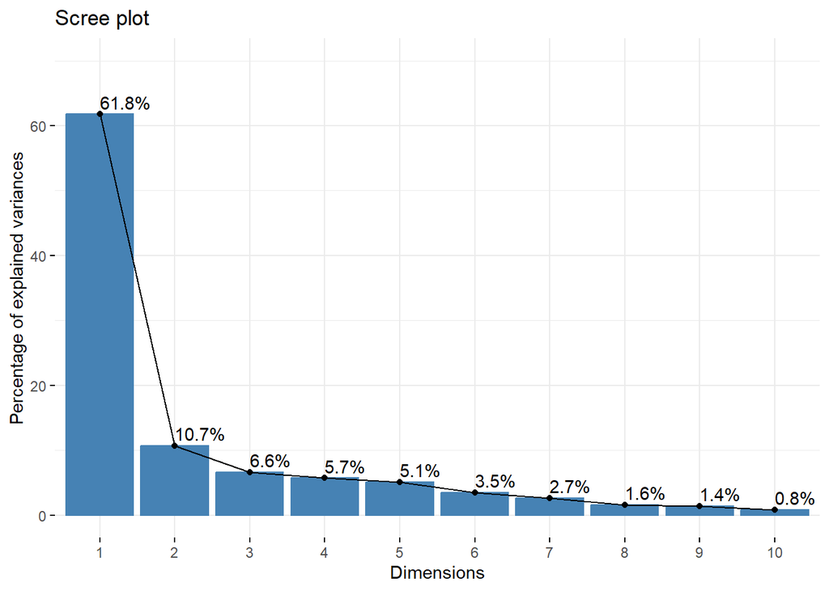

```r
fviz_screeplot(res.pca, addlabels = TRUE, ylim = c(0, 70), ncp=10)
```

```r
names(res.pca$var)
```

```
## [1] "coord"   "cor"     "cos2"    "contrib"
```

Conclusion :: Le critère de coude conduit aussi à retenir les 2 premiers axes. ==>Après la réalisation de ces 3 critères on va retenir les 2 premiers axes.

### *Cercle de corrélation :

La corrélation entre une variable et une composante principale (PC) est utilisée comme coordonnées de la variable sur la composante principale. La représentation des variables diffère de celle des observations : les observations sont représentées par leurs projections, mais les variables sont représentées par leurs corrélations.

#### Qualité de représentation :

##### méthode1:

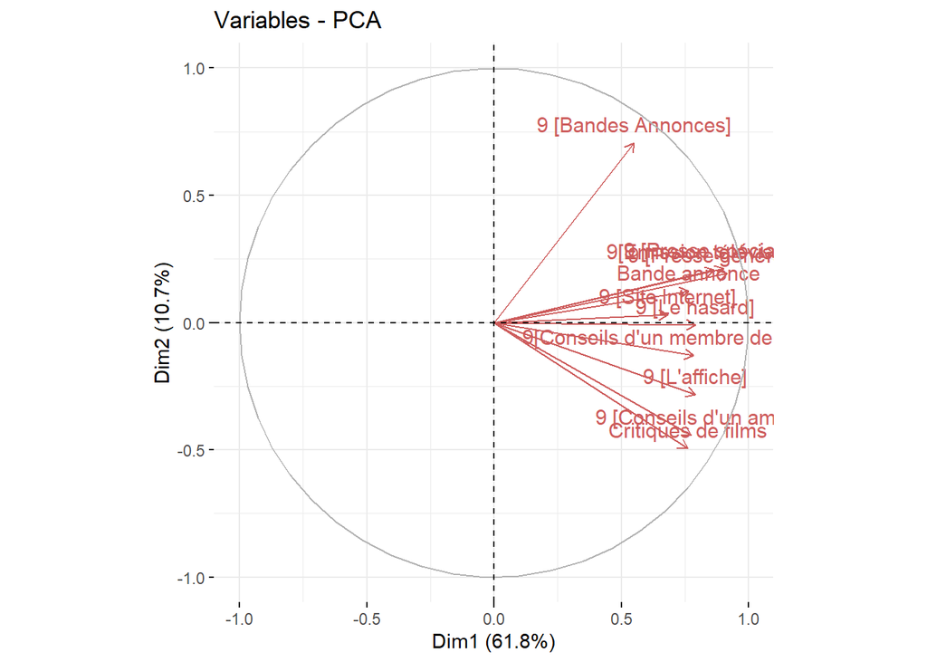

```r
fviz_pca_var(res.pca, col.var = "indianred",col.quanti.sup="darkblue" )
```

Le graphique ci-dessus montre que les variables les plus corrélées à l’axe 1 sont : Emission télevisuelle , les presses..(Réseaux sociaux) On peut voir aussi que les variables les plus corrélées à l’axe 2 sont : Bandes Annonces , Critiques de films,conseil d’un amis.

##### méthode2:

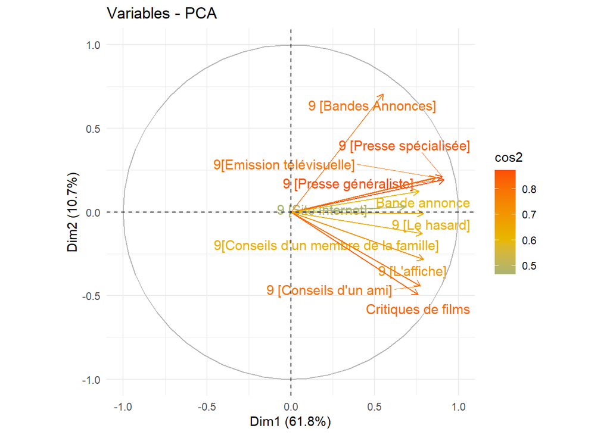

```r
fviz_pca_var(res.pca, col.var="cos2",gradient.cols = c("#00AFBB", "#E7B800", "#FC4E07"), repel = TRUE) +
  scale_color_gradient2(low="#00AFBB", mid="#E7B800",
                        high="#FC4E07", midpoint=0.6) +
  theme_minimal()
```

Interpretation : La variable {conseils d’amis} est positivement corrélée a la variable {critique de films } et {affiche} . L’individus(es) qui est influée par la l’affiche est plus influée par la conseils d’amis et critique de films lors du choix du film

### *Contribution :

#### Premier axe :

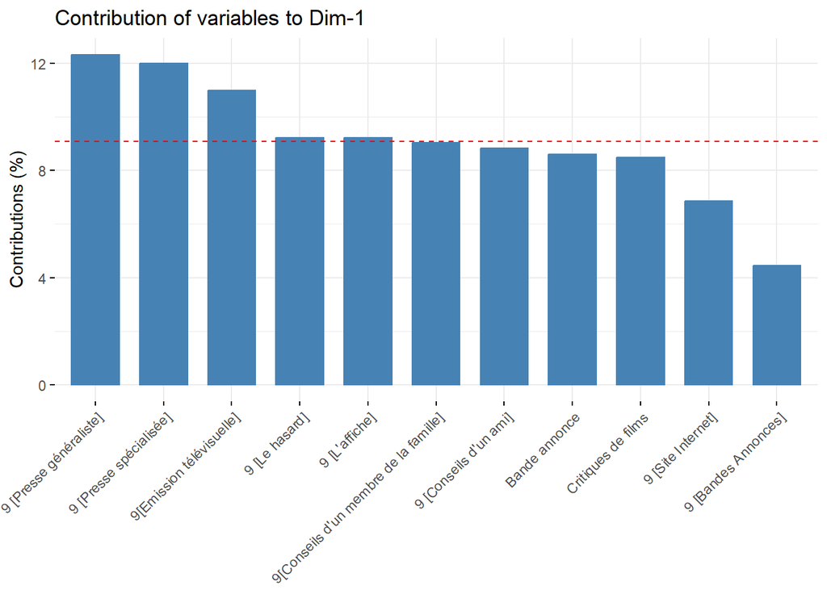

```r
fviz_contrib(res.pca, choice = "var", axes = 1, top = 30)
```

Presse généraliste, Presse spécialisée , Emission télévisuelle sont les variables qui ont un rôle dominant dans la formation du premier axe factoriel.

#### Deuxiéme axe :

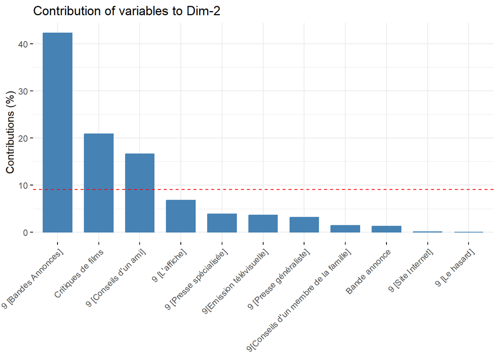

```r
fviz_contrib(res.pca, choice = "var", axes = 2, top = 30)
```

Bandes Annonces, Critiques de films et Conseils d’un ami sont les variables qui ont un rôle dominant dans la formation du deuxiéme axe factoriel.

### *Graphique des individus :

#### carte des individus:

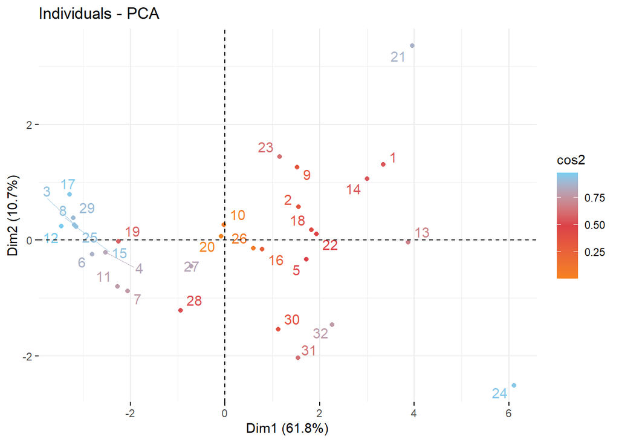

```r
fviz_pca_ind (res.pca, col.ind = "cos2",
gradient.cols = c("#f6821f", "#dc4048", "#7acdf1"),
repel = TRUE)
```

Le prémier axe oppose des individus tels que 14 1 9 23 21 9 (à droite du graphe, caractérisés par une coordonnée fortement positive sur l’axe) à des individus comme 28 11 3 7 11 (à gauche du graphe , caractérisés par une coordonnée fortement négative sur l’axe).

*Le groupe auquel les individus 14 1 21 appartiennent (caractérisés par une coordonnée positive sur l’axe 1) partage : De fortes valeurs pour les variables : les presses, emission televisuelle…

*Le groupe auquel les individus 17 8 4 12 4 11 appartiennent (caractérisés par une coordonnée négative sur l’axe) partage : bande d’annance …

## 4/-Classification :

### *Visualisation des individus et les grouper :

```r
library(NbClust)
library(cluster)

cl3 = kmeans(X, centers = 2)
cl3$cluster
```

```
##  [1] 1 1 2 2 1 2 2 2 1 1 2 2 1 1 2 1 2 1 2 1 1 1 1 1 2 1 2 2 2 1 1 1
```

```r
cl3$centers
```

```
##   9 [Presse spécialisée] 9 [Presse généraliste] 9 [Site Internet]
## 1               3.555556               3.388889          2.666667
## 2               1.071429               1.071429          1.357143
##   9[Emission télévisuelle] Bande annonce 9 [Conseils d'un ami]
## 1                 3.000000      2.666667                   2.5
## 2                 1.142857      1.428571                   1.5
##   9[Conseils d'un membre de la famille] Critiques de films 9 [Bandes Annonces]
## 1                              3.222222           2.833333            2.388889
## 2                              1.285714           1.285714            1.071429
##   9 [L'affiche] 9 [Le hasard]
## 1      2.666667      2.833333
## 2      1.357143      1.500000
```

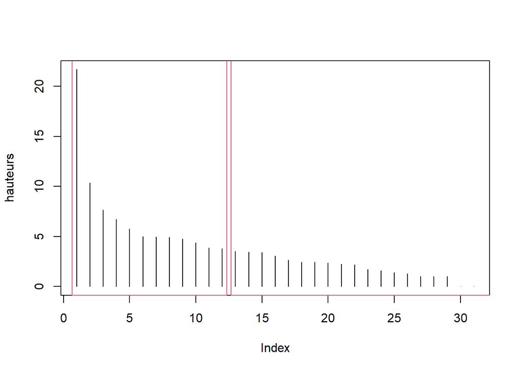

```r
classif<-agnes(X, method="ward")
d=dist(scale(X),method = "euclidian")
hc1=hclust(d,method = "ward.D") # or complete or average
classif2<-as.hclust(classif)
plot(rev(classif2$height), type="h", ylab="hauteurs")
rect.hclust(hc1,k=2)
```

```r
classes<-cutree(classif2,k=2)
classes
```

```
##  [1] 1 1 2 2 1 2 2 2 1 1 2 2 1 1 2 1 2 1 2 1 1 1 1 1 2 1 1 2 2 1 1 1
```

```r
nc <- NbClust(X, min.nc = 2, max.nc = 10, method = "kmeans")
```

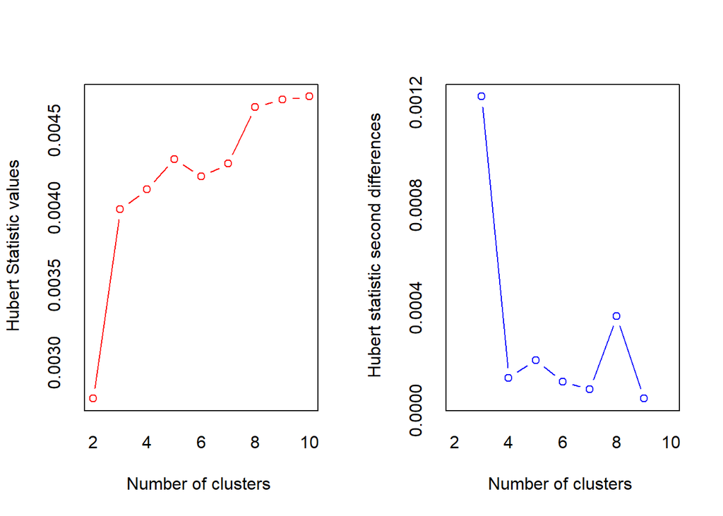

```
## *** : The Hubert index is a graphical method of determining the number of clusters.
##                 In the plot of Hubert index, we seek a significant knee that corresponds to a
##                 significant increase of the value of the measure i.e the significant peak in Hubert
##                 index second differences plot.
##
```

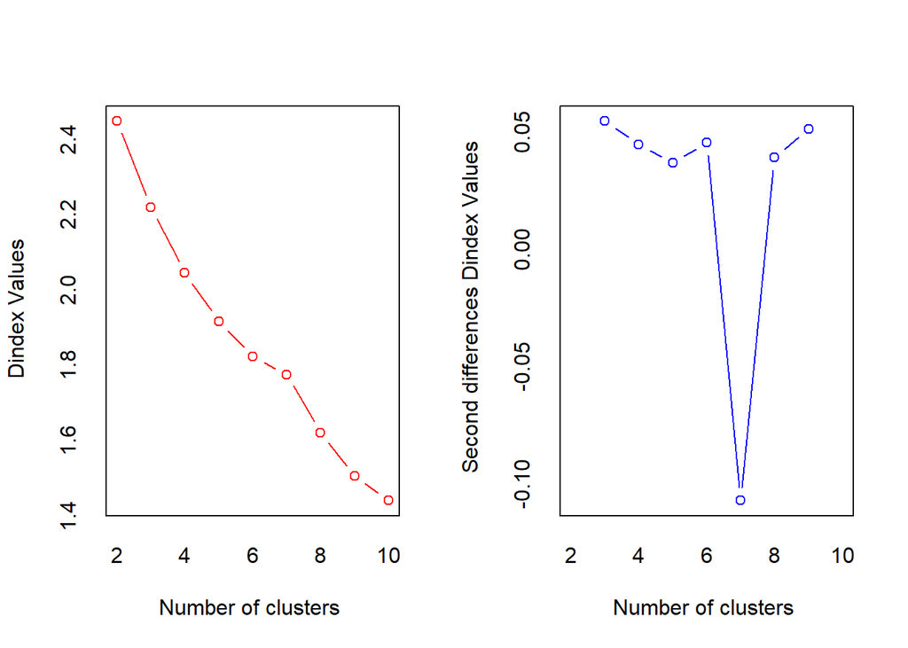

```
## *** : The D index is a graphical method of determining the number of clusters.
##                 In the plot of D index, we seek a significant knee (the significant peak in Dindex
##                 second differences plot) that corresponds to a significant increase of the value of
##                 the measure.
##
## * Among all indices:
## * 9 proposed 2 as the best number of clusters
## * 5 proposed 3 as the best number of clusters
## * 1 proposed 4 as the best number of clusters
## * 3 proposed 5 as the best number of clusters
## * 1 proposed 7 as the best number of clusters
## * 1 proposed 8 as the best number of clusters
## * 2 proposed 9 as the best number of clusters
## * 1 proposed 10 as the best number of clusters
##
##                    ***** Conclusion *****
##
## * According to the majority rule, the best number of clusters is  2
##
##
```

```r
nc
```

```
## $All.index
##         KL      CH Hartigan     CCC    Scott      Marriot   TrCovW   TraceW
## 2   4.9299 30.8162   8.4317  6.0552 133.6734 3.999802e+12 538.7106 234.6825
## 3   2.2941 23.1560   4.3168  3.2594 189.9292 1.551435e+12 447.8165 183.1945
## 4   0.7226 18.5130   5.3241  2.7108 246.4589 4.714187e+11 369.1383 159.4583
## 5  15.6394 17.2182   0.6575  2.7875 321.0467 7.160488e+10 240.2916 133.9821
## 6   4.8815 13.7140   0.7887  1.7378 349.3440 4.258565e+10 236.6771 130.7972
## 7   0.0094 11.4485   6.9400  0.4792 370.9828 2.947685e+10 228.4941 126.9464
## 8   6.8055 12.9874   1.4428  1.7799 413.7831 1.010630e+10 127.7612  99.3631
## 9   3.2821 11.7180   0.7169  1.1365 522.0424 4.341443e+08 146.5502  93.7286
## 10  3.2052 10.3499   0.3038 -0.0647 538.1425 3.240739e+08 140.9841  90.8952
##     Friedman   Rubin Cindex     DB Silhouette   Duda Pseudot2   Beale Ratkowsky
## 2   344.4202  9.2124 0.4849 0.8827     0.4154 0.7446   5.4876  2.4033    0.4837
## 3   382.4059 11.8017 0.4250 1.3826     0.3601 1.9075  -6.6605 -3.2696    0.4340
## 4   444.8512 13.5584 0.3855 1.5496     0.2827 0.8130   1.6101  1.4679    0.3925
## 5   587.8928 16.1365 0.4487 1.3740     0.2970 3.3835  -9.1578 -4.7680    0.3671
## 6   701.1326 16.5294 0.4267 1.3317     0.2148 1.5315  -3.1235 -2.2609    0.3400
## 7   787.8596 17.0308 0.4582 1.3582     0.1536 6.7222  -2.5537  0.0000    0.3173
## 8   734.4856 21.7586 0.5035 1.2346     0.1791 1.1978  -1.6517 -1.0541    0.3102
## 9  1478.6212 23.0666 0.4317 1.1590     0.2321 1.5136  -0.3393 -1.2632    0.2929
## 10 1570.6103 23.7856 0.4336 1.0317     0.2498 0.7292   1.8571  2.3045    0.2792
##        Ball Ptbiserial    Frey McClain   Dunn Hubert SDindex Dindex   SDbw
## 2  117.3413     0.5839  0.1859  0.6051 0.2255 0.0028  1.0893 2.4468 0.4621
## 3   61.0648     0.6856  1.2496  0.8552 0.2449 0.0040  1.4401 2.2184 0.5305
## 4   39.8646     0.6112  0.0848  1.3341 0.2828 0.0041  1.6417 2.0444 0.4786
## 5   26.7964     0.6290 -2.0377  1.3726 0.3536 0.0043  1.5283 1.9150 0.4396
## 6   21.7995     0.5041 -0.7450  2.1177 0.2774 0.0042  1.6096 1.8221 0.3280
## 7   18.1352     0.4120  0.0042  2.9453 0.1601 0.0043  2.0936 1.7747 0.3030
## 8   12.4204     0.4422  0.2160  3.0084 0.2000 0.0046  1.9910 1.6202 0.3164
## 9   10.4143     0.4392 -1.4083  3.1449 0.1768 0.0047  1.8039 1.5047 0.2465
## 10   9.0895     0.4293 -0.3773  3.2883 0.1768 0.0047  1.9022 1.4403 0.2077
##
## $All.CriticalValues
##    CritValue_Duda CritValue_PseudoT2 Fvalue_Beale
## 2          0.6326             9.2929       0.0084
## 3          0.5911             9.6829       1.0000
## 4          0.4778             7.6498       0.1651
## 5          0.5630            10.0896       1.0000
## 6          0.5044             8.8438       1.0000
## 7          0.0135           218.9289          NaN
## 8          0.4778            10.9283       1.0000
## 9          0.1839             4.4371       1.0000
## 10         0.4458             6.2167       0.0210
##
## $Best.nc
##                      KL      CH Hartigan    CCC    Scott     Marriot   TrCovW
## Number_clusters  5.0000  2.0000   7.0000 2.0000   9.0000 3.00000e+00   5.0000
## Value_Index     15.6394 30.8162   6.1514 6.0552 108.2593 1.36835e+12 128.8467
##                  TraceW Friedman   Rubin Cindex     DB Silhouette   Duda
## Number_clusters  3.0000   9.0000  8.0000 4.0000 2.0000     2.0000 2.0000
## Value_Index     27.7519 744.1356 -3.4198 0.3855 0.8827     0.4154 0.7446
##                 PseudoT2   Beale Ratkowsky    Ball PtBiserial Frey McClain
## Number_clusters   2.0000  3.0000    2.0000  3.0000     3.0000    1  2.0000
## Value_Index       5.4876 -3.2696    0.4837 56.2764     0.6856   NA  0.6051
##                   Dunn Hubert SDindex Dindex    SDbw
## Number_clusters 5.0000      0  2.0000      0 10.0000
## Value_Index     0.3536      0  1.0893      0  0.2077
##
## $Best.partition
##  [1] 2 2 1 1 2 1 1 1 2 2 1 1 2 2 1 2 1 2 1 2 2 2 2 2 1 2 1 1 1 2 2 2
```

```r
#2. Déterminer la meilleure partition
set.seed(1234)
nc_km <- NbClust(X, min.nc = 2, max.nc = 15, method = "kmeans" )
```

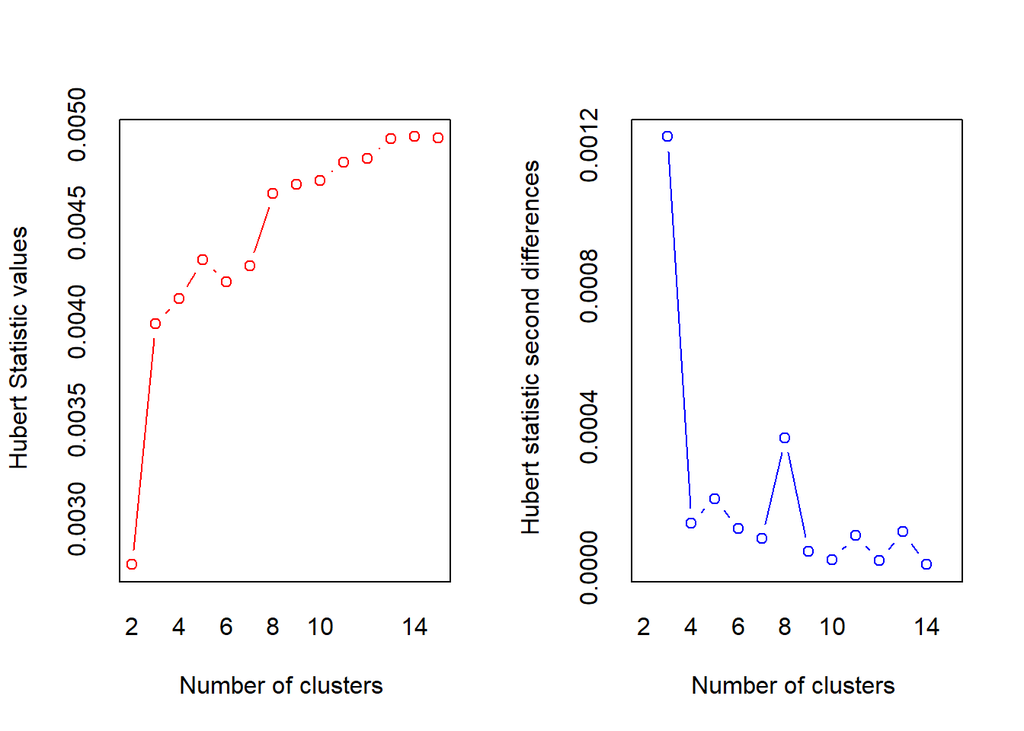

```
## *** : The Hubert index is a graphical method of determining the number of clusters.
##                 In the plot of Hubert index, we seek a significant knee that corresponds to a
##                 significant increase of the value of the measure i.e the significant peak in Hubert
##                 index second differences plot.
##
```

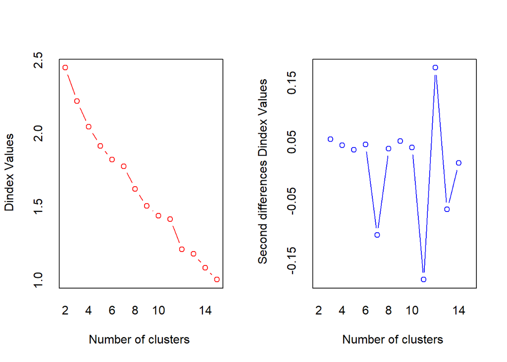

```
## *** : The D index is a graphical method of determining the number of clusters.
##                 In the plot of D index, we seek a significant knee (the significant peak in Dindex
##                 second differences plot) that corresponds to a significant increase of the value of
##                 the measure.
##
## * Among all indices:
## * 9 proposed 2 as the best number of clusters
## * 4 proposed 3 as the best number of clusters
## * 1 proposed 4 as the best number of clusters
## * 3 proposed 5 as the best number of clusters
## * 1 proposed 9 as the best number of clusters
## * 3 proposed 12 as the best number of clusters
## * 1 proposed 13 as the best number of clusters
## * 1 proposed 15 as the best number of clusters
##
##                    ***** Conclusion *****
##
## * According to the majority rule, the best number of clusters is  2
##
##
```

```r
# On a utilis? 26 crit?res pour calculer la qualit? des classifications
sum(table(nc_km$Best.n[1, ]))
```

```
## [1] 26
```